# MSE210 Lab4: Simple Data Collection and Data visualization

## In-person activities

### Exercise 1

Turn the Galton board upside-down so that all the beads reach the top hopper. Start recording your exp and immediately turn the Galton board so that the beads start to fall down. Stop your video when the last bead has fallen and note down the approximate time for Galton board to empty. Repeat the experiment 1 more time.

### Exercise 2

Measure the hight of the rubber feet of the Galton board, the distance between the feet as well as the overhang (length of plastic that extends beyond the legs). Use a pencil or a pen that is 7.5-10mm (note down this value) to prop-up the left edge of the Galton board (to the left of the feet,such that the rubber feet do not rest on your pencil/pen). Repeat Exercise 1 (ie run the Galton board and record the video).

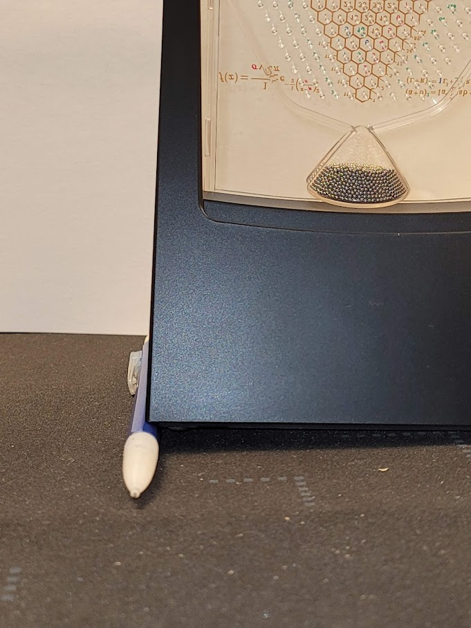

### Exercise 3

Move your pencil or pen to the middle of the Galton board. Repeat Exercise 1 (ie run the Galton board and record the video 2 times).

### Exercise 4

Move your pencil or pen to the right edge of the Galton board just beyond the feet and repeat Exercise 1 (ie run the Galton board and record the video 2 times).

## In-home activity

For each of the 8 videos, open the video either on you phone or on your computer and export the frames (or stills images) for when the Galton board is 50% and 100% complete. You will now have 16 images.

Get WebPlotDigitizer from https://automeris.io/WebPlotDigitizer/ – you may either use th online version or download it on your computer. Follow the video help to measure the height of the column of bearings. Save the data as “ex1_1a.csv”, “ex1_1a.csv” etc. and save them in a folder titled data. Open each file: Remove the word “bar” by finding and replacing “Bar” with ““, and add”Bin, Count” as the first line (this would serve as the column names). For each file load the data by running ex1_1a = read_csv(“data/ex1_1a.csv”). [You may optionally call ex1_1a = read_csv(“data/ex1_1a.csv”, show_col_types = FALSE)]

```r
ex1_1a = read_csv("data/ex1_1a.csv", show_col_types = FALSE)
```

You can view the data by typing glimpse(ex1_1a)

```r
glimpse(ex1_1a)
```

[output not shown]

### Exercise 1

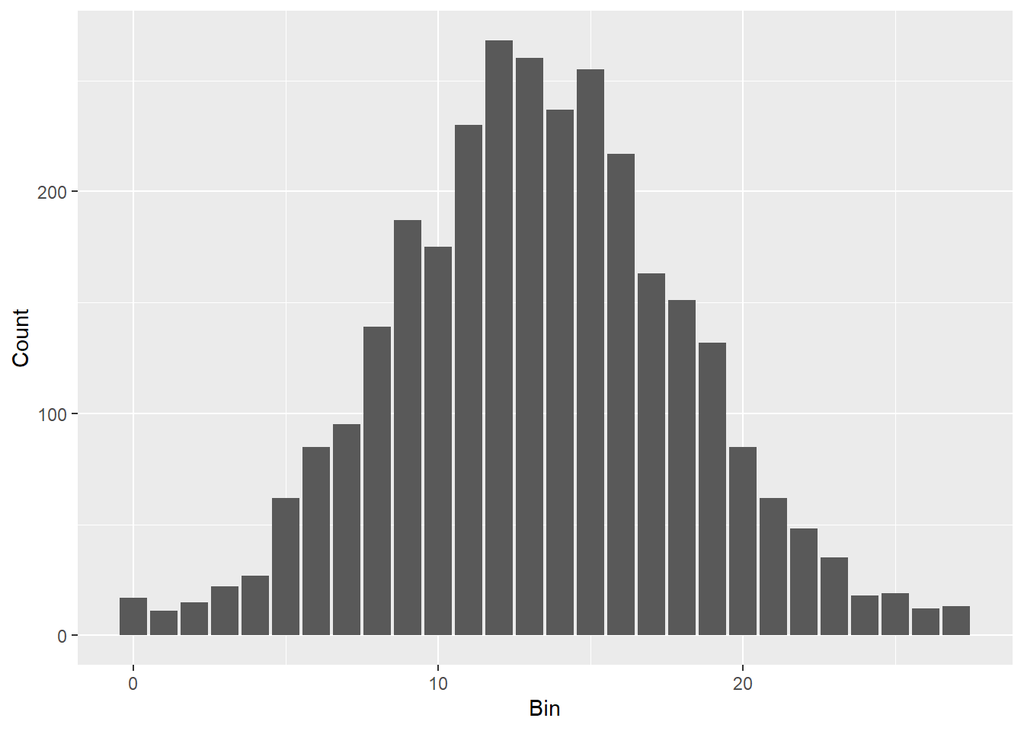

```r
ggplot(data = ex1_1a) +
  geom_bar(aes(x=Bin,y=Count),stat='identity')
```

### Exercise 2

Calculate the mean and standard deviation of the data by using the “sum” function (note ** stands for power function in R). You can use “cat” to join outputs to make your output pretty.

```r
df = ex1_1a;
Mean = sum(df$Bin*df$Count)/sum(df$Count)
SD = sqrt(sum((df$Bin-Mean)**2*df$Count)/(sum(df$Count)-1))
cat("Mean=",Mean,"\n","Sample-SD=",SD)
```

[output not shown]

### Exercise 3.

How do means compare between the different cases ?

### Excerise 4.

How does tilting the Galton board vary the results (Try to use the height of the legs, the distance between legs and the height of the pen to make conclusions) ?